# AdvancedRNA-seq

Simon Tomlinson

12/03/2021

## Advanced RNA-Seq Data Analysis Using R

### Simon Tomlinson FGT 2021

-Create a directory to store this week’s files and unpack the archive file for tutorial8 into this folder. tar -xvf FGT_T8_RNAseq_tutorial.tar -Set this as the current working directory -Set the root dir in the markdown (r setup chunk) –eg as an example knitr::opts_knit$set(root.dir = “./fgt2022/tutorial8/FGT_T8_RNAseq_tutorial/”) -Then load and run this script

Once we have loaded the data we are ready to run some further analysis.

Further processing to remove unwanted samples and create the required object for the differential gene analysis using DESeq (https://bioconductor.org/packages/release/bioc/html/DESeq.html).

```r
#keep-remove XO samples
keep_cols=adf$Sex[idx]!="O"
#create object for DESeq
#NOTE the design for differential analysis is fed into this object- the adf annotates each sample
dds_rnaseq <- DESeqDataSetFromMatrix(countData=table_rnaseq[,keep_cols],
                                     colData=adf[keep_cols,],
                                     design=~ Line + Sex)
#check the object dimensions
dim(dds_rnaseq)
```

```
## [1] 55471    12
```

```r
head(rownames(dds_rnaseq))
```

```
## [1] "ENSMUSG00000102693" "ENSMUSG00000064842" "ENSMUSG00000051951"
## [4] "ENSMUSG00000102851" "ENSMUSG00000103377" "ENSMUSG00000104017"
```

```r
colnames(dds_rnaseq)
```

```
##  [1] "BCF1" "BCF2" "BCF3" "BCM1" "BCM2" "BCM3" "CBF1" "CBF3" "CBF4" "CBM1"
## [11] "CBM2" "CBM3"
```

```r
#check the object type
class(dds_rnaseq)
```

```
## [1] "DESeqDataSet"
## attr(,"package")
## [1] "DESeq2"
```

```r
typeof(dds_rnaseq)
```

```
## [1] "S4"
```

```r
#check what this object contains
slotNames(dds_rnaseq)
```

```
## [1] "design"             "dispersionFunction" "rowRanges"
## [4] "colData"            "assays"             "NAMES"
## [7] "elementMetadata"    "metadata"
```

```r
colnames(colData(dds_rnaseq))
```

```
##  [1] "BioSample"               "AvgSpotLen"
##  [3] "Bases"                   "Bytes"
##  [5] "Experiment"              "GEO_Accession"
##  [7] "SampleName"              "source_name"
##  [9] "ShortName"               "X_chromosome_complement"
## [11] "Line"                    "Sex"
## [13] "Colour"
```

```r
colnames(assay(dds_rnaseq))
```

```
##  [1] "BCF1" "BCF2" "BCF3" "BCM1" "BCM2" "BCM3" "CBF1" "CBF3" "CBF4" "CBM1"
## [11] "CBM2" "CBM3"
```

Apply filters to remove genes that do not pass quality filters.

```
## [1] 39454
```

```
## [1] 22124
```

```
##      BCF1      BCF2      BCF3      BCM1      BCM2      BCM3      CBF1      CBF3
## 1.7458333 2.6125334 1.0996490 0.8547024 1.2482526 1.5679083 0.7300116 0.8285179
##      CBF4      CBM1      CBM2      CBM3
## 1.2059458 0.5164399 0.4392925 0.8192294
```

DESeq2 also provides methods that outputs data with various normalisations….

```r
# Normalised log counts
counts_rnaseq <- log2(counts(dds_rnaseq, normalized=TRUE))
# fpm is similar to cpm (https://rdrr.io/bioc/DESeq2/man/fpm.html)
# Here the data is log transformed
fpm_rnaseq <- log(fpm(dds_rnaseq))
# this is also normalised by the sizeFactors
# rlog and vsd are discussed here https://genomebiology.biomedcentral.com/articles/10.1186/s13059-014-0550-8
vsd_rnaseq <- vst(dds_rnaseq, blind = T)
head(vsd_rnaseq, 3)
```

```
## class: DESeqTransform
## dim: 3 12
## metadata(1): version
## assays(1): ''
## rownames(3): ENSMUSG00000051951 ENSMUSG00000103161 ENSMUSG00000102331
## rowData names(4): baseMean baseVar allZero dispFit
## colnames(12): BCF1 BCF2 ... CBM2 CBM3
## colData names(14): BioSample AvgSpotLen ... Colour sizeFactor
```

```r
rld_rnaseq <- rlog(dds_rnaseq, blind = T)
head(rld_rnaseq, 3)
```

```
## class: DESeqTransform
## dim: 3 12
## metadata(1): version
## assays(1): ''
## rownames(3): ENSMUSG00000051951 ENSMUSG00000103161 ENSMUSG00000102331
## rowData names(7): baseMean baseVar ... dispFit rlogIntercept
## colnames(12): BCF1 BCF2 ... CBM2 CBM3
## colData names(14): BioSample AvgSpotLen ... Colour sizeFactor
```

We will use rlog for the rest of this tutorial. Note that differential expression uses counts- rlog is just for visualisation.

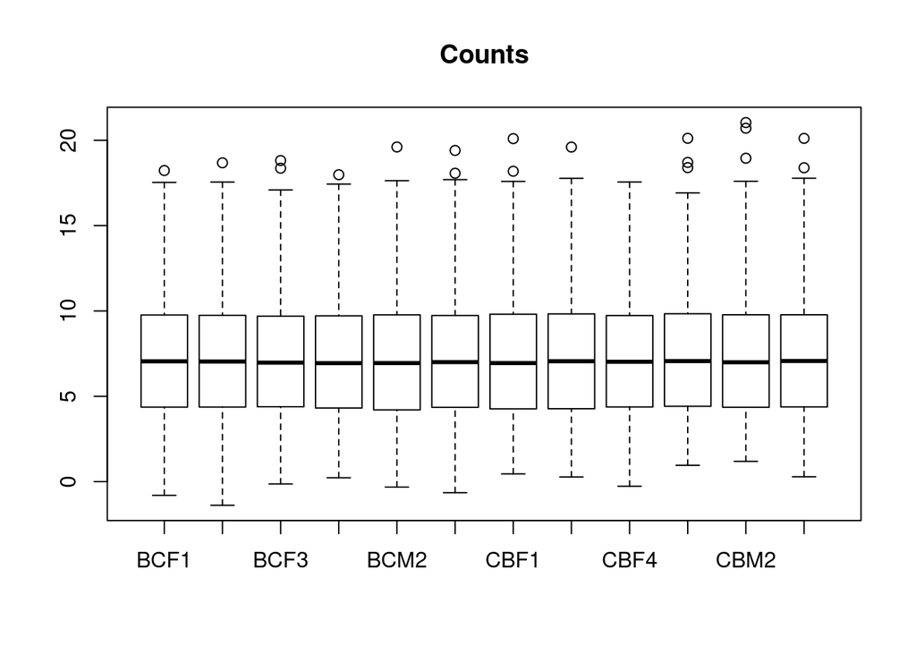

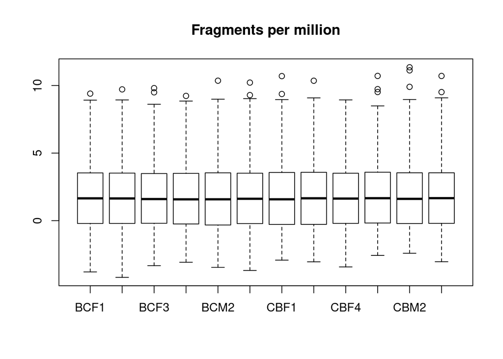

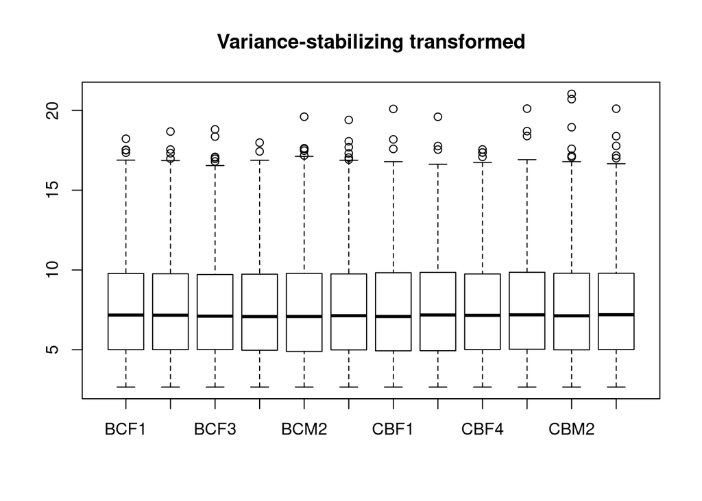

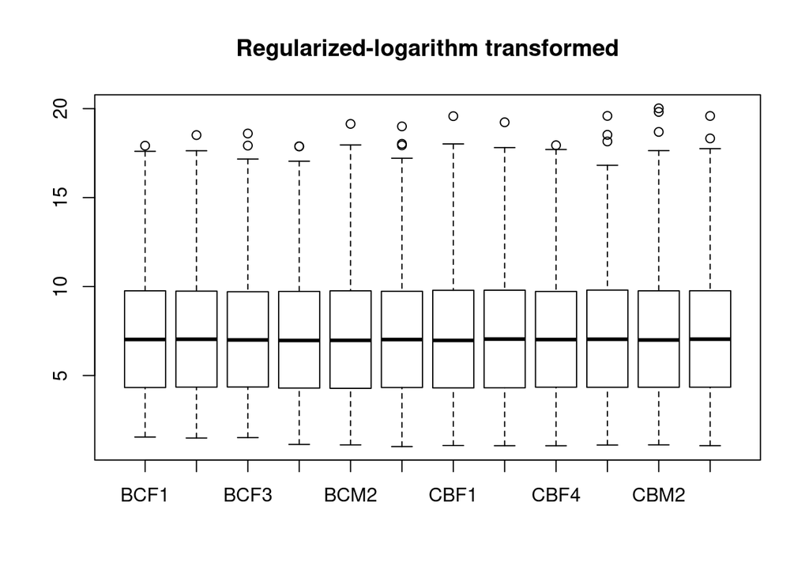

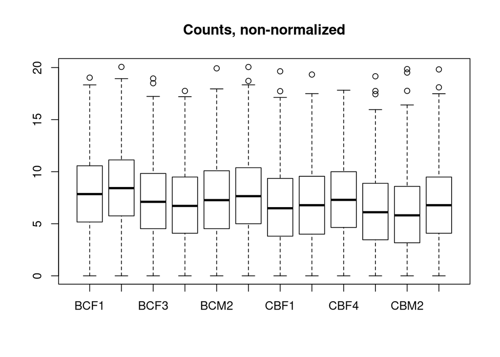

PCA plots similar to those we use for microarrays.

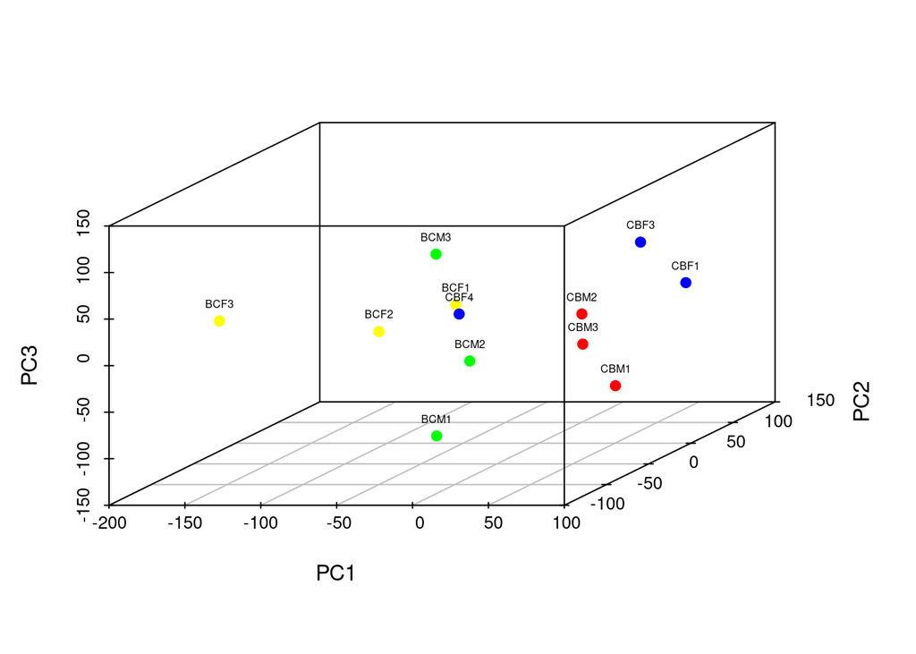

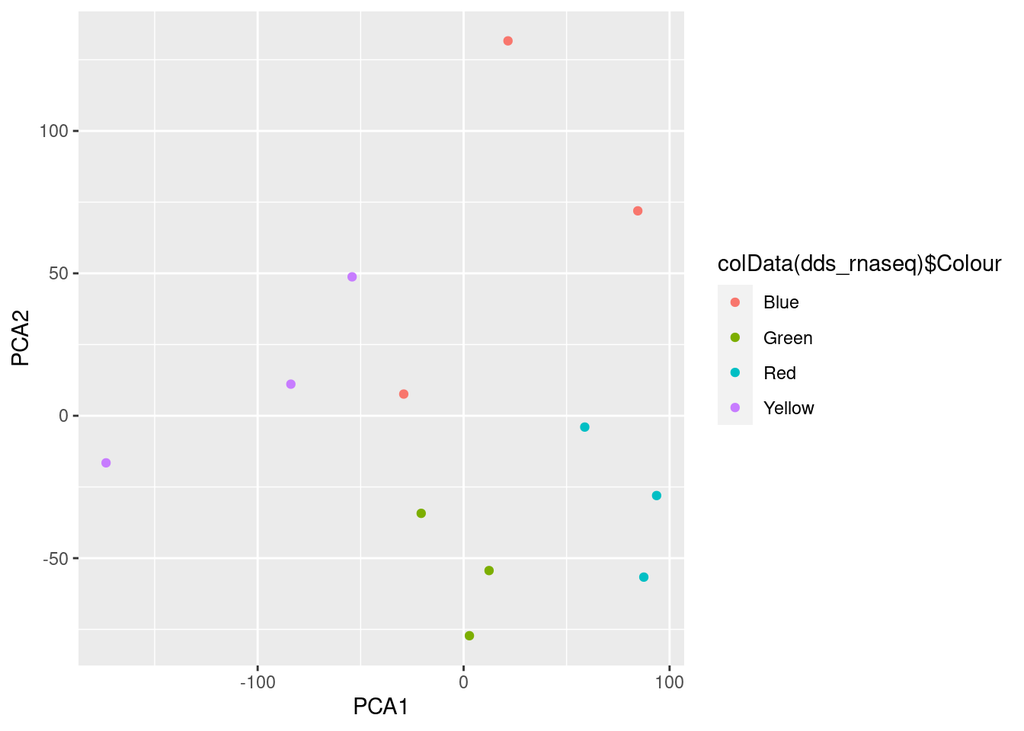

```
##          BCF1     BCF2     BCF3     BCM1     BCM2     BCM3     CBF1     CBF3
## BCF2 33.13616
## BCF3 57.08878 39.18985
## BCM1 52.93050 52.63006 70.81025
## BCM2 54.47474 55.34643 76.26103 40.47564
## BCM3 61.64383 66.80690 82.52075 60.39348 44.95991
## CBF1 65.15346 73.26611 96.50425 69.54170 61.28100 69.51084
## CBF3 55.22970 63.95491 84.33881 69.69528 66.62949 71.79241 49.13125
## CBF4 44.38613 46.12309 64.23257 50.87930 49.35572 57.01915 56.90380 54.20601
## CBM1 68.19707 71.38158 92.55223 57.34261 51.58753 64.95507 56.39799 63.60840
## CBM2 71.99683 74.35206 94.86418 65.97212 52.96722 58.03658 50.88363 68.03018
## CBM3 58.41987 59.50658 81.14669 53.70279 48.06279 61.02539 46.83494 53.11433
##          CBF4     CBM1     CBM2
## BCF2
## BCF3
## BCM1
## BCM2
## BCM3
## CBF1
## CBF3
## CBF4
## CBM1 58.43343
## CBM2 60.12811 47.76897
## CBM3 49.84960 37.64947 39.49864
```

Generate further heatmaps with the data

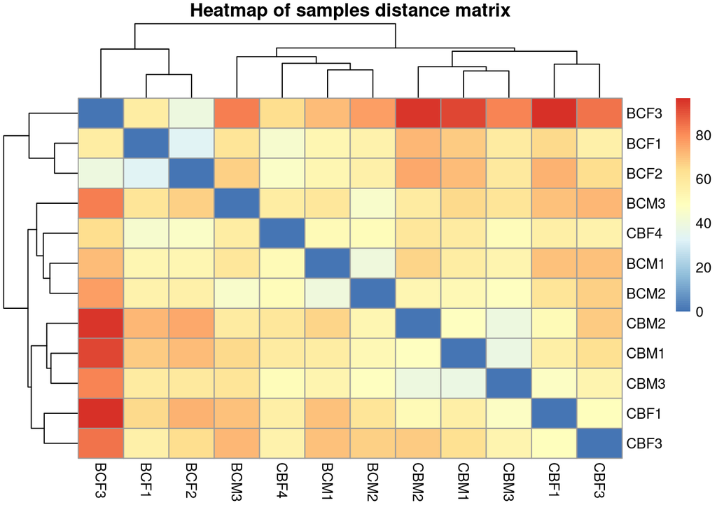

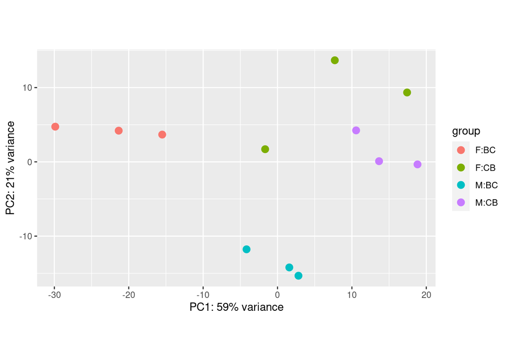

Differential Gene Expression  
Here we perform a two factor analysis using DESeq2.  
The design was fed into the dds_rnaseq object and was specified out as ~Line + Sex which specifies two factors Sex and Line.  
Sex and Line are colnames in the annotation able and samples are therefore annotated with these labels. Statistics in DESeq2 works in a similar way to Limma but is designed for count data.

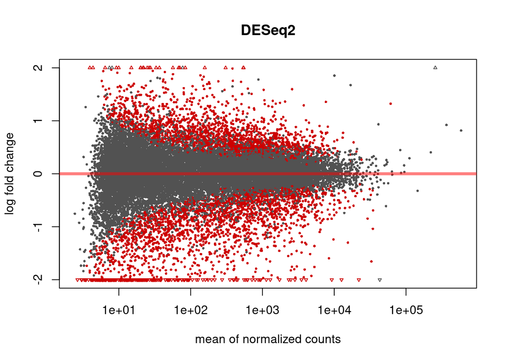

```
##
## FALSE  TRUE
## 20546  1564
```

```
##
## FALSE  TRUE
## 20385  1725
```

```
##
## FALSE  TRUE
## 19157  2953
```

```
##
## FALSE  TRUE
## 18737  3373
```

```
## log2 fold change (MLE): Sex M vs F
## Wald test p-value: Sex M vs F
## DataFrame with 6 rows and 6 columns
##                            baseMean    log2FoldChange             lfcSE
##                           <numeric>         <numeric>         <numeric>
## ENSMUSG00000069053  24.857047853336  8.33355342473663  1.21060038624253
## ENSMUSG00000072479 8.81960022765008 -6.17708049324933   1.0379139628403
## ENSMUSG00000067764 21.4492269670259 -6.02777578996537  1.16061405197567
## ENSMUSG00000083847  15.091202271888 -5.16248645645931  1.24009277181755
## ENSMUSG00000058328 20.8981750531337 -5.11176284508431 0.816502502021854
## ENSMUSG00000054215 18.0533670725589 -5.01067557277425  0.68430578245827
##                                 stat               pvalue                 padj
##                            <numeric>            <numeric>            <numeric>
## ENSMUSG00000069053  6.88381857418895 5.82690772109178e-12 2.22125740885068e-09
## ENSMUSG00000072479 -5.95143789794045 2.65796876148024e-09 4.73932978357485e-07
## ENSMUSG00000067764 -5.19360917585351 2.06255895727966e-07 1.83145295363266e-05
## ENSMUSG00000083847 -4.16298407166173 3.14115287619872e-05 0.000964504681362237
## ENSMUSG00000058328 -6.26055992777287 3.83597622286301e-10 9.52959935814621e-08
## ENSMUSG00000054215 -7.32227565690606 2.43800687628509e-13 1.73884942047301e-10
```

Make heatmaps from each of the output tables- selected top 50 or all using fold change and FDR.

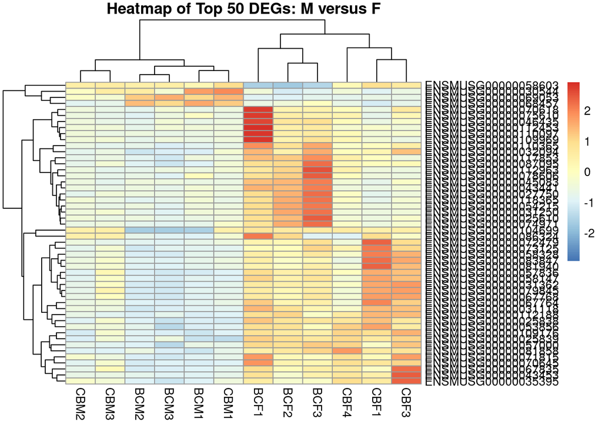